# Project Proposal

Kossi Akplaka

2023-10-29

### Data Preparation

```r
library(dplyr)
library(tidyverse)
```

Let’s load the data in a data frame

```r
Complaint_data <- read.csv("https://raw.githubusercontent.com/Kossi-Akplaka/Data606-Stats_and_Probability_in_R/main/Project%20Proposal/NYPD_Complaint_Data_Historic.csv")
```

Let’s have a glimpse of the data.

```r
glimpse(Complaint_data)
```

```
## Rows: 28,504
## Columns: 40
## $ CMPLNT_NUM             <int> 223783375, 222530820, 222530689, 222530997, 222…
## $ CMPLNT_FR_DT           <chr> "1/2/2021", "1/2/2021", "1/2/2021", "1/2/2021",…
## $ CMPLNT_FR_TM           <chr> "19:00:00", "23:48:00", "23:14:00", "23:00:00",…
## $ CMPLNT_TO_DT           <chr> "1/2/2021", "1/2/2021", "1/2/2021", "1/2/2021",…
## $ CMPLNT_TO_TM           <chr> "19:30:00", "23:55:00", "23:24:00", "23:08:00",…
## $ ADDR_PCT_CD            <int> 61, 71, 108, 113, 79, 79, 44, 52, 79, 103, 23, …
## $ RPT_DT                 <chr> "1/30/2021", "1/3/2021", "1/3/2021", "1/3/2021"…
## $ KY_CD                  <int> 118, 118, 235, 118, 118, 118, 118, 235, 118, 23…
## $ OFNS_DESC              <chr> "DANGEROUS WEAPONS", "DANGEROUS WEAPONS", "DANG…
## $ PD_CD                  <int> 792, 793, 511, 792, 793, 792, 792, 569, 792, 51…
## $ PD_DESC                <chr> "CRIMINAL POSSESSION WEAPON", "WEAPONS POSSESSI…
## $ CRM_ATPT_CPTD_CD       <chr> "COMPLETED", "COMPLETED", "COMPLETED", "COMPLET…
## $ LAW_CAT_CD             <chr> "FELONY", "FELONY", "MISDEMEANOR", "FELONY", "F…
```

[output cut: 27 more lines]

We can look up the missing values. As a reminder, the missing values in this data is recorded as (null)

```r
# Look up the missing values
missing_data <- Complaint_data %>%
  summarise_all(~ sum(.=="(null)"))

print(missing_data)
```

```
##   CMPLNT_NUM CMPLNT_FR_DT CMPLNT_FR_TM CMPLNT_TO_DT CMPLNT_TO_TM ADDR_PCT_CD
## 1          0            0            0            0         3374           0
##   RPT_DT KY_CD OFNS_DESC PD_CD PD_DESC CRM_ATPT_CPTD_CD LAW_CAT_CD BORO_NM
## 1      0     0         0     0       0                0          0      10
##   LOC_OF_OCCUR_DESC PREM_TYP_DESC JURIS_DESC JURISDICTION_CODE PARKS_NM
## 1             11891            26          0                 0    28163
##   HADEVELOPT HOUSING_PSA X_COORD_CD Y_COORD_CD SUSP_AGE_GROUP SUSP_RACE
## 1      28397       26141          0          0           7182      7182
##   SUSP_SEX TRANSIT_DISTRICT Latitude Longitude Lat_Lon PATROL_BORO STATION_NAME
## 1     7182               NA        0         0       0           0        26275
##   VIC_AGE_GROUP VIC_RACE VIC_SEX Zip.Codes Community.Districts
## 1             0        0       0        NA                  NA
##   Borough.Boundaries City.Council.Districts Police.Precincts
## 1                 NA                     NA               NA
```

This data frame has a lot of columns. We can drop the column that has a lot of missing values and the columns we are going to use for the analysis

```r
Complaint_data <- Complaint_data %>%
  select(- CMPLNT_NUM,  # Unique ID of the records
         - PARKS_NM,
         - HADEVELOPT,
         - HOUSING_PSA,
         - STATION_NAME,
         -LOC_OF_OCCUR_DESC,
         - Latitude,
         - Longitude,
         - Lat_Lon)  # A lot of missing values
```

### Research question

- Is there on average a significant difference in response time by law enforcement agencies for incidents involving ‘DANGEROUS WEAPONS’ compared to ‘DANGEROUS DRUGS’?
- Is there on average a significant difference in response times to reported incidents of ‘DANGEROUS WEAPONS’ between ‘Queens’ and ‘Manhattan’?

### Data collection

This dataset includes all valid felony, misdemeanor, and violation crimes reported to the New York City Police Department (NYPD) from 2006 to the end of last year (2022). The data was found on https://data.cityofnewyork.us/Public-Safety/NYPD-Complaint-Data-Historic/qgea-i56i

The original data has more than 8.3 million complaints. I filtered the data between 1/1/2021 to 12/31/2022.

I’ve also filtered the offenses description “OFNS_DESC”. I was only interested in DANGEROUS DRUGS and DANGEROUS WEAPONS offenses.

The final data was saved as a CSV file and uploaded to my GitHub: https://raw.githubusercontent.com/Kossi-Akplaka/Data606-Stats_and_Probability_in_R/main/Project%20Proposal/NYPD_Complaint_Data_Historic.csv

### Type of study

This is an observational study.

### Data Source

The data was available online. The data was found on https://data.cityofnewyork.us/Public-Safety/NYPD-Complaint-Data-Historic/qgea-i56i

### Dependent Variable

The response variable represents the Response Time (minutes) and it is quantitative.

### Independent Variable(s)

Question 1: The independent variables are the category of the reported crime, which can be “DANGEROUS WEAPONS” or “DANGEROUS DRUGS” and it is categorical.

Question 2: Location (Categorical) - “QUEENS” and “MANHATTAN”, Type of Crime (Categorical) - ‘DANGEROUS WEAPONS’

### Relevant summary statistics

Create a new column called “response_time” which is the difference between the time NYPD came vs Exact time of occurrence for the reported event

```r
Complaint_data <- Complaint_data %>%
  mutate(CMPLNT_FR_TM = as.POSIXlt(CMPLNT_FR_TM, format = "%H:%M:%S"),
         CMPLNT_TO_TM = as.POSIXlt(CMPLNT_TO_TM, format = "%H:%M:%S"))


Complaint_data <- Complaint_data %>%
  mutate(response_time = difftime(CMPLNT_TO_TM, CMPLNT_FR_TM, units = "mins"))

head(Complaint_data$response_time)
```

```
## Time differences in mins
## [1] 30  7 10  8  5  5
```

Let’s plot the distribution of the response time for ‘DANGEROUS WEAPONS’ and ‘DANGEROUS DRUGS’ side by side.

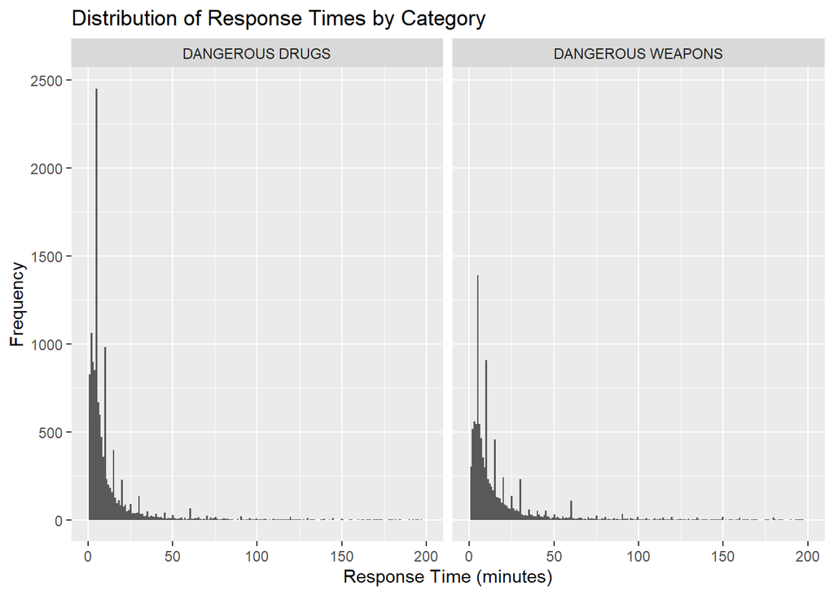

```r
# Let's clean the data to remove the NA in the column response time( some of the rows in the data didn't have time)

Clean_data <- Complaint_data %>%
  filter(response_time != 'NA mins')

# Now we can plot the clean data
ggplot(Clean_data, aes(x = as.numeric(response_time))) +
  geom_histogram(bins = 200) +
  labs(
    title = "Distribution of Response Times by Category",
    x = "Response Time (minutes)",
    y = "Frequency"
  ) +
  xlim(0, 200) +
  facet_wrap(~OFNS_DESC, ncol = 2)
```

Let’s plot the distribution of the response time for ‘DANGEROUS WEAPONS’ for ‘QUEENS’.

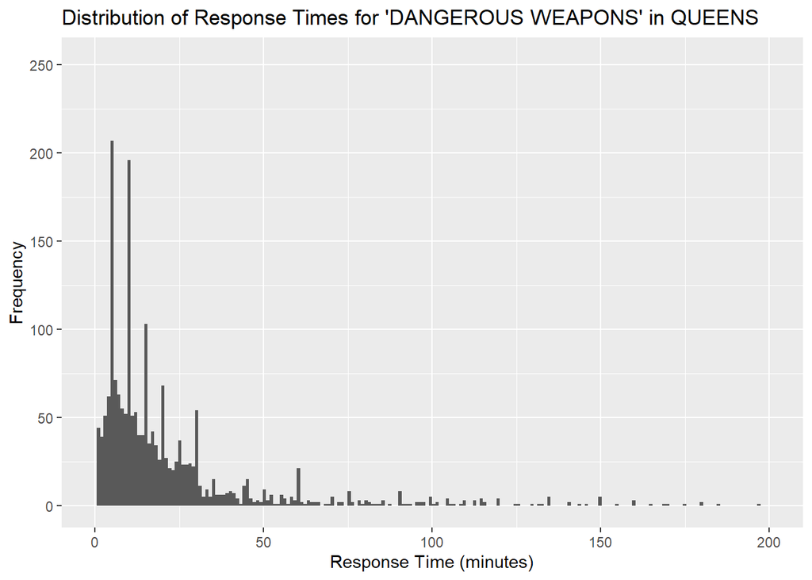

```r
# Filter the data for 'DANGEROUS WEAPONS' in 'QUEENS'
filtered_data <- Clean_data %>%
  filter(OFNS_DESC == 'DANGEROUS WEAPONS' & (BORO_NM == 'QUEENS'))

# Create a histogram of response times for 'DANGEROUS WEAPONS' in 'QUEENS'
ggplot(filtered_data, aes(x = as.numeric(response_time))) +
  geom_histogram(bins = 200) +
  labs(
    title = "Distribution of Response Times for 'DANGEROUS WEAPONS' in QUEENS",
    x = "Response Time (minutes)",
    y = "Frequency"
  ) +
  xlim(0, 200)
```

Let’s plot the distribution of the response time for ‘DANGEROUS WEAPONS’ for ‘MANHATTAN’.

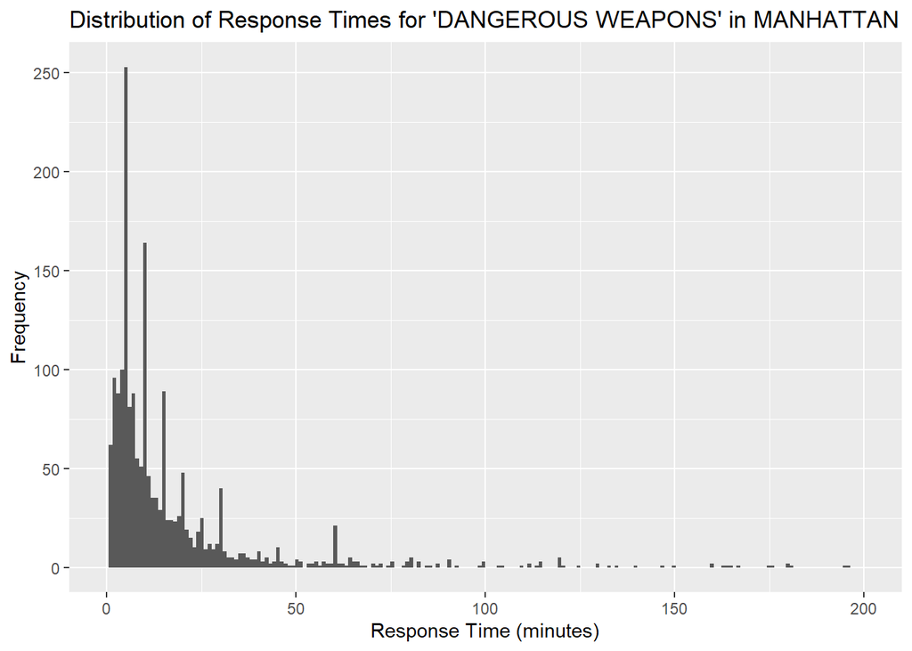

```r
# Filter the data for 'DANGEROUS WEAPONS' in 'MANHATTAN'
filtered_data <- Clean_data %>%
  filter(OFNS_DESC == 'DANGEROUS WEAPONS' & (BORO_NM == 'MANHATTAN'))

# Create a histogram of response times for 'DANGEROUS WEAPONS' in 'QUEENS'
ggplot(filtered_data, aes(x = as.numeric(response_time))) +
  geom_histogram(bins = 200) +
  labs(
    title = "Distribution of Response Times for 'DANGEROUS WEAPONS' in MANHATTAN",
    x = "Response Time (minutes)",
    y = "Frequency"
  ) +
  xlim(0, 200)
```